# DFO Reference Points 101

## Exercise 4: Reference points using an age-structured model. Influence of *h*, *M*, and selectivity

Seven operating models were conditioned to age-composition data for the catch and a survey index for a herring stock (1968-2020) using various assumptions for *h* and *M* and future selectivity. An R object is provided for each operating model that contains the relevant data for the exercise. The models were conditioned using a Beverton-Holt stock-recruit relationship (SHH) with assumed *h* (0.6, 0.8, or 0.95) over the first 5 years, and a constant *M* (0.2, 0.3, of 0.4) for all years and ages. In this exercise we look at the influence of the assumptions of *h*, *M*, and selectivity on estimates of *SSB*<sub>MSY</sub> and *SSB*<sub>0</sub>.

```r
OM <- c("A","B","C","D","E","F","G")
h <- c(0.8,0.6,0.95,rep(0.8,4))
M <- c(rep(0.3,3),0.2,0.4,rep(0.3,2))
sel <- c(rep('mat',5),'low','high')

T0<-data.frame(OM,h,M,Selectivity=sel,Fmsy=NA,SSBmsy=NA,SSB0=NA)
T0[,1:4] %>% kbl(align=c(rep('c',7))) %>% kable_styling()
```

| OM | h | M | Selectivity |
| --- | --- | --- | --- |
| A | 0.80 | 0.3 | mat |
| B | 0.60 | 0.3 | mat |
| C | 0.95 | 0.3 | mat |
| D | 0.80 | 0.2 | mat |
| E | 0.80 | 0.4 | mat |
| F | 0.80 | 0.3 | low |
| G | 0.80 | 0.3 | high |

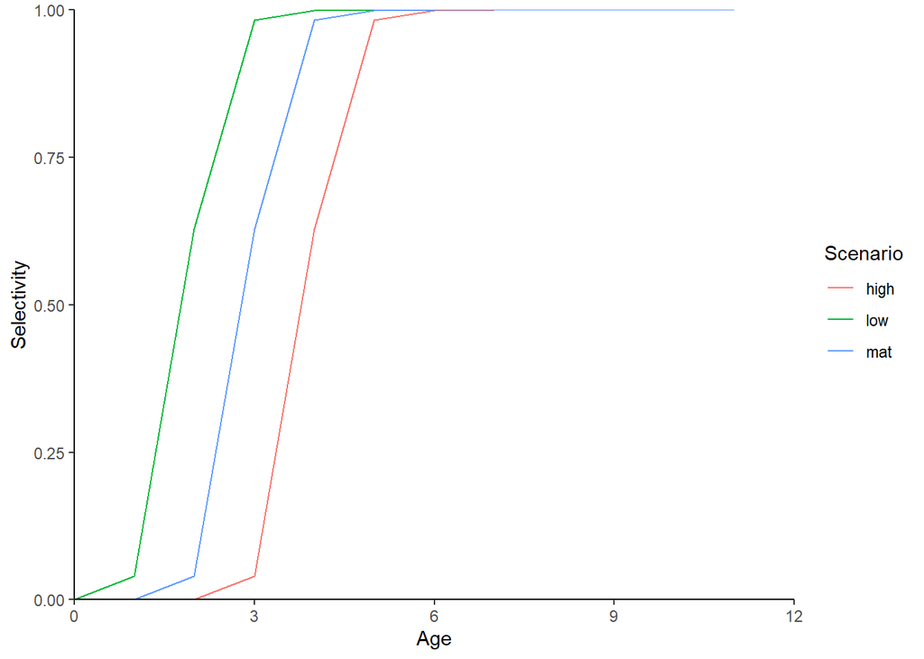

```r
source("source_ftns.r")
MOD <- getOMs(n=7) #get OMs: generates a list with the OM objects for 7 different models
```

Exercise Questions:

1. Estimate *F*<sub>MSY</sub>, *SSB*<sub>MSY</sub>, and *SSB*<sub>0</sub> for each of the 7 OMs. The code to extract the data from the OMs is below. The reference point calculations can be added to the loop below.

```r
for(i in 1:7){
  MFit<-MOD[[OM[i]]]
  year <- MFit@OM@nyears     #Year; vector of length 53
  ssb <- apply(MFit@SSB,2,mean)[1:length(year)]  #SSB 1968-2020; vector of length 54
  rec <- MFit@mean_fit$report$R[1:length(year)]  #Age 0 recruitment 1968-2020; vector of length 54
  bha <- MFit@mean_fit$report$Arec      #constant Beverton-Holt a parameter
  bhb <- MFit@mean_fit$report$Brec      #constant Beverton-Holt b parameter
  waa <- MFit@OM@cpars$Wt_age[1,,length(year)]     #Weight-at-age; array of dimension 12x53 with ages 0 to 11+
  mat <- MFit@OM@cpars$Mat_age[1,,1]                 #maturity-at-age; vector of length 12, constant all years
  sel <- mat
  if(i==6){sel <- c(mat[2:12],1) } # low selectivity scenario
  if(i==7){sel <- c(0,mat[1:11]) } # high selectivity scenario
  M <- MFit@OM@cpars$M_ageArray[1,1,1]

  # Add reference point calculations and save in dataframe T0

}
```

2. Calculate the ratio $\frac{SSB_{MSY}}{SSB_0}$ for each OM. Which variable (*h*, *M*, or *selectivity*) is the most influential on this ratio?
3. Plot the relative yield vs. *F* and relative yield vs. relative equilibrium SSB curves for OMs A,B,C (*h* variable)
4. Plot the relative yield vs. *F* and relative yield vs. relative equilibrium SSB curves for OMs A,D,E (*M* variable)
5. Plot the relative yield vs. *F* and relative yield vs. relative equilibrium SSB curves for OMs A,F,G (*selectivity* variable)

The loop below can help with Questions 3 to 5 where yield, f, and equilibrium SSB are stored in an array

```r
f=seq(0,5,0.001)
RES <- array(NA,dim=c(7,length(f),5),dimnames=list(OM,f,c('phi','YPR','Eq_SSB','Eq_rec','Yield')))

#for(i in 1:7){
#  MFit<-MOD[[OM[i]]]
#  year <- MFit@OM@nyears     #Year; vector of length 53
#  bha <- MFit@mean_fit$report$Arec      #constant Beverton-Holt a parameter
#  bhb <- MFit@mean_fit$report$Brec      #constant Beverton-Holt b parameter
#  waa <- MFit@OM@cpars$Wt_age[1,,length(year)]     #Weight-at-age; array of dimension 12x53 with ages 0 to 11+
#  mat <- MFit@OM@cpars$Mat_age[1,,1]                 #maturity-at-age; vector of length 12, constant all years
#  sel <- mat
#  if(i==6){sel <- c(mat[2:12],1) } # low selectivity scenario
#  if(i==7){sel <- c(0,mat[1:11]) } # high selectivity scenario
#  M <- MFit@OM@cpars$M_ageArray[1,1,1]

#  for(j in 1:length(f)){
#    RES[i,j,'phi'] <-
#    RES[i,j,'YPR'] <-
#    RES[i,j,'Eq_SSB'] <-
#    RES[i,j,'Eq_rec'] <-
#    RES[i,j,'Yield'] <-
#  }
#}
```

Solutions:

1. and 2.

```r
for(i in 1:7){
  MFit<-MOD[[OM[i]]]
  year <- MFit@OM@nyears     #Year; vector of length 53
  ssb <- apply(MFit@SSB,2,mean)[1:length(year)]  #SSB 1968-2020; vector of length 54
  rec <- MFit@mean_fit$report$R[1:length(year)]  #Age 0 recruitment 1968-2020; vector of length 54
  bha <- MFit@mean_fit$report$Arec      #constant Beverton-Holt a parameter
  bhb <- MFit@mean_fit$report$Brec      #constant Beverton-Holt b parameter
  waa <- MFit@OM@cpars$Wt_age[1,,length(year)]     #Weight-at-age; array of dimension 12x53 with ages 0 to 11+
  mat <- MFit@OM@cpars$Mat_age[1,,1]                 #maturity-at-age; vector of length 12, constant all years
  sel <- mat
  if(i==6){sel <- c(mat[2:12],1) } # low selectivity scenario
  if(i==7){sel <- c(0,mat[1:11]) } # high selectivity scenario
  M <- MFit@OM@cpars$M_ageArray[1,1,1]

  RP <- RPcalc(M,waa,mat,sel,a=bha,b=bhb)
  T0$Fmsy[i] <- RP$Fmsy
  T0$SSBmsy[i] <- RP$SSBmsy
  T0$SSB0[i] <- RP$SSB0
}

T0$SSBmsy_SSB0 <- T0$SSBmsy/T0$SSB0 # h most influential
T0
```

```
##   OM    h   M Selectivity Fmsy   SSBmsy     SSB0 SSBmsy_SSB0
## 1  A 0.80 0.3         mat 0.50 238.4829 862.0458   0.2766476
## 2  B 0.60 0.3         mat 0.29 299.8253 882.7286   0.3396574
## 3  C 0.95 0.3         mat 0.79 189.5991 844.3401   0.2245530
## 4  D 0.80 0.2         mat 0.31 244.4192 874.1947   0.2795935
## 5  E 0.80 0.4         mat 0.75 250.9068 919.6176   0.2728382
## 6  F 0.80 0.3         low 0.29 263.3802 876.2764   0.3005675
## 7  G 0.80 0.3        high 1.25 226.5135 850.9487   0.2661894
```

3. to 5.

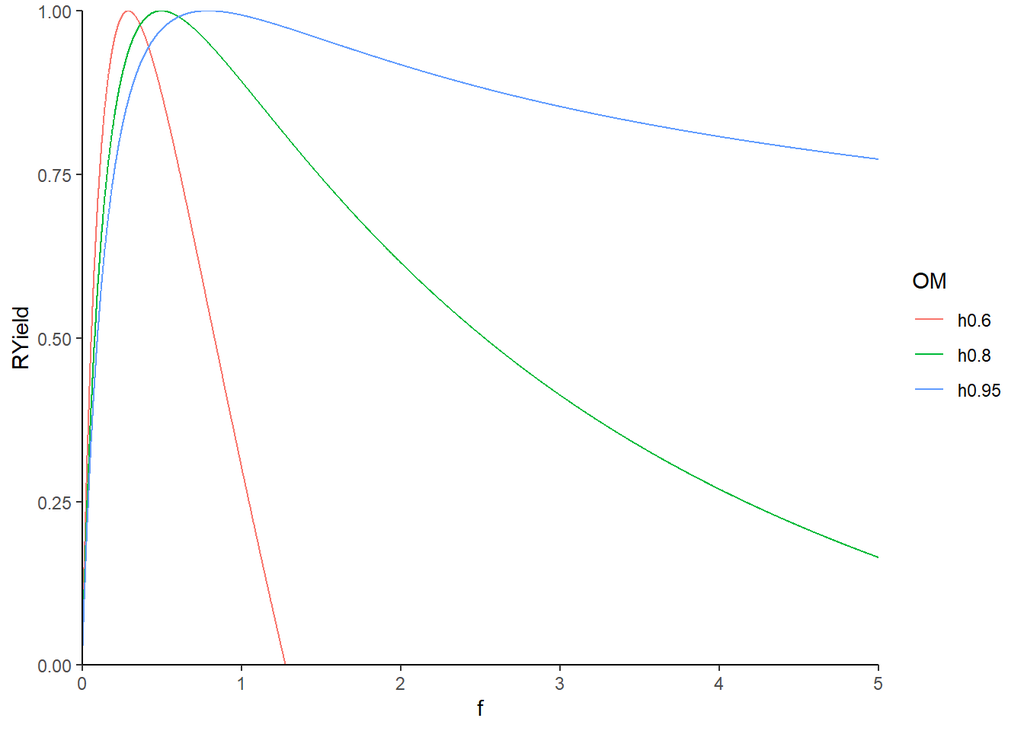

```r
f=seq(0,5,0.001)
RES <- array(NA,dim=c(7,length(f),5),dimnames=list(OM,f,c('phi','YPR','Eq_SSB','Eq_rec','Yield')))

for(i in 1:7){
  MFit<-MOD[[OM[i]]]
  year <- MFit@OM@nyears     #Year; vector of length 53
  bha <- MFit@mean_fit$report$Arec      #constant Beverton-Holt a parameter
  bhb <- MFit@mean_fit$report$Brec      #constant Beverton-Holt b parameter
  waa <- MFit@OM@cpars$Wt_age[1,,length(year)]     #Weight-at-age; array of dimension 12x53 with ages 0 to 11+
  mat <- MFit@OM@cpars$Mat_age[1,,1]                 #maturity-at-age; vector of length 12, constant all years
  sel <- mat
  if(i==6){sel <- c(mat[2:12],1) } # low selectivity scenario
  if(i==7){sel <- c(0,mat[1:11]) } # high selectivity scenario
  M <- MFit@OM@cpars$M_ageArray[1,1,1]

  for(j in 1:length(f)){
    surv <- survivorship_F(f=f[j],M=M,n_ages=length(sel),sel=sel)
    RES[i,j,'phi'] <- sum(surv*waa*mat)
    RES[i,j,'YPR'] <- sum(surv*waa*(1-exp(-M-f[j]*sel))*f[j]*sel/(M+f[j]*sel))
    RES[i,j,'Eq_SSB'] <- (bha*RES[i,j,'phi']-1)/bhb
    RES[i,j,'Eq_rec'] <- bha*RES[i,j,'Eq_SSB']/(1+bhb*RES[i,j,'Eq_SSB'])
    RES[i,j,'Yield'] <- RES[i,j,'YPR']*RES[i,j,'Eq_rec']
  }
}

D1 <- data.frame(OM=rep(c("h0.8","h0.6","h0.95"),each=length(f)),f=rep(f,3),RYield=c(RES[1,,'Yield']/max(RES[1,,'Yield']),RES[2,,'Yield']/max(RES[2,,'Yield']),RES[3,,'Yield']/max(RES[3,,'Yield'])),REq_SSB=c(RES[1,,'Eq_SSB']/max(RES[1,,'Eq_SSB']),RES[2,,'Eq_SSB']/max(RES[2,,'Eq_SSB']),RES[3,,'Eq_SSB']/max(RES[3,,'Eq_SSB'])))

D2 <- data.frame(OM=rep(c("M0.3","M0.2","M0.4"),each=length(f)),f=rep(f,3),RYield=c(RES[1,,'Yield']/max(RES[1,,'Yield']),RES[4,,'Yield']/max(RES[4,,'Yield']),RES[5,,'Yield']/max(RES[5,,'Yield'])),REq_SSB=c(RES[1,,'Eq_SSB']/max(RES[1,,'Eq_SSB']),RES[4,,'Eq_SSB']/max(RES[4,,'Eq_SSB']),RES[5,,'Eq_SSB']/max(RES[5,,'Eq_SSB'])))


D3 <- data.frame(OM=rep(c("sel_mat","sel_low","sel_high"),each=length(f)),f=rep(f,3),RYield=c(RES[1,,'Yield']/max(RES[1,,'Yield']),RES[6,,'Yield']/max(RES[6,,'Yield']),RES[7,,'Yield']/max(RES[7,,'Yield'])),REq_SSB=c(RES[1,,'Eq_SSB']/max(RES[1,,'Eq_SSB']),RES[6,,'Eq_SSB']/max(RES[6,,'Eq_SSB']),RES[7,,'Eq_SSB']/max(RES[7,,'Eq_SSB'])))



ggplot(D1)+geom_path(mapping=aes(y=RYield,x=f,colour=OM)) + theme_classic() +
  scale_x_continuous(limits = c(0,5), expand = c(0, 0)) +
  scale_y_continuous(limits = c(0,1), expand = c(0, 0))
```

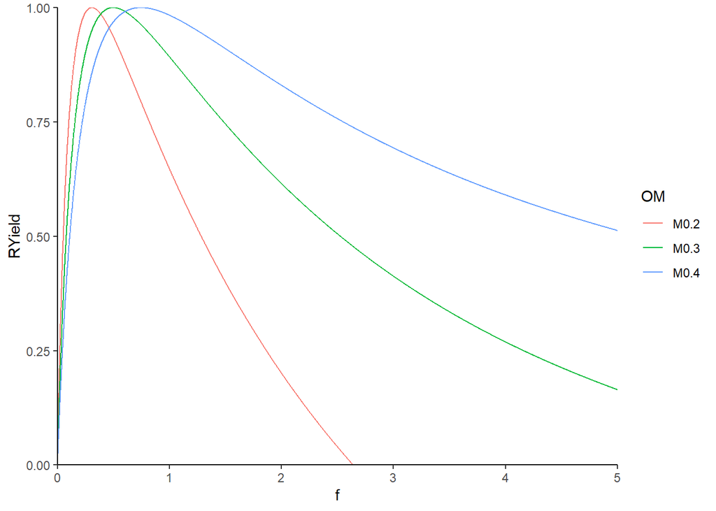

```r
ggplot(D2)+geom_path(mapping=aes(y=RYield,x=f,colour=OM)) + theme_classic() +
  scale_x_continuous(limits = c(0,5), expand = c(0, 0)) +
  scale_y_continuous(limits = c(0,1), expand = c(0, 0))
```

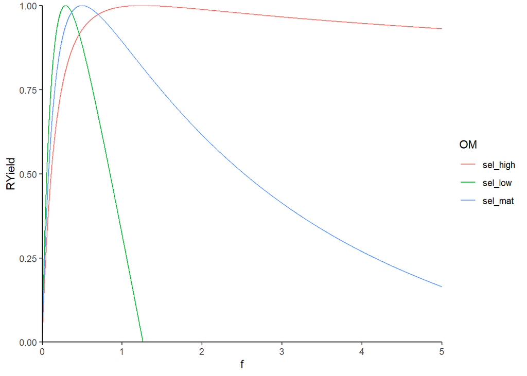

```r
ggplot(D3)+geom_path(mapping=aes(y=RYield,x=f,colour=OM)) + theme_classic() +
  scale_x_continuous(limits = c(0,5), expand = c(0, 0)) +
  scale_y_continuous(limits = c(0,1), expand = c(0, 0))
```

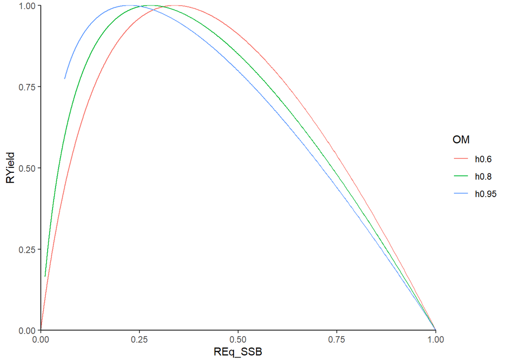

```r
ggplot(D1)+geom_path(mapping=aes(y=RYield,x=REq_SSB,colour=OM)) + theme_classic() +
  scale_x_continuous(limits = c(0,1), expand = c(0, 0)) +
  scale_y_continuous(limits = c(0,1), expand = c(0, 0))
```

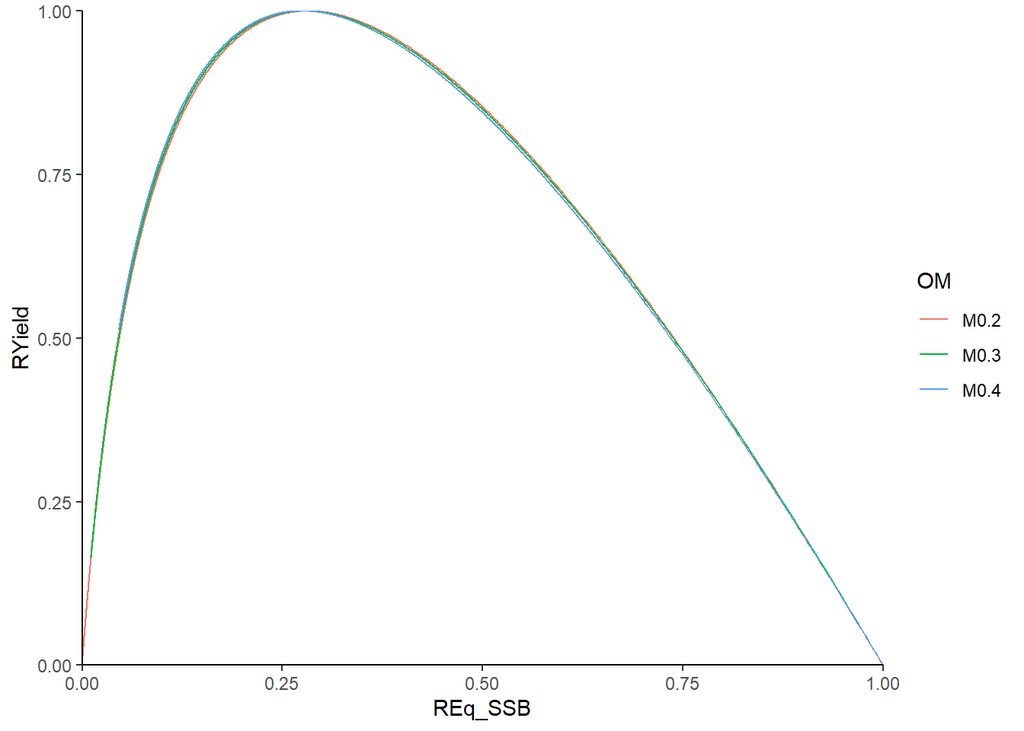

```r
ggplot(D2)+geom_path(mapping=aes(y=RYield,x=REq_SSB,colour=OM)) + theme_classic() +
  scale_x_continuous(limits = c(0,1), expand = c(0, 0)) +
  scale_y_continuous(limits = c(0,1), expand = c(0, 0))
```

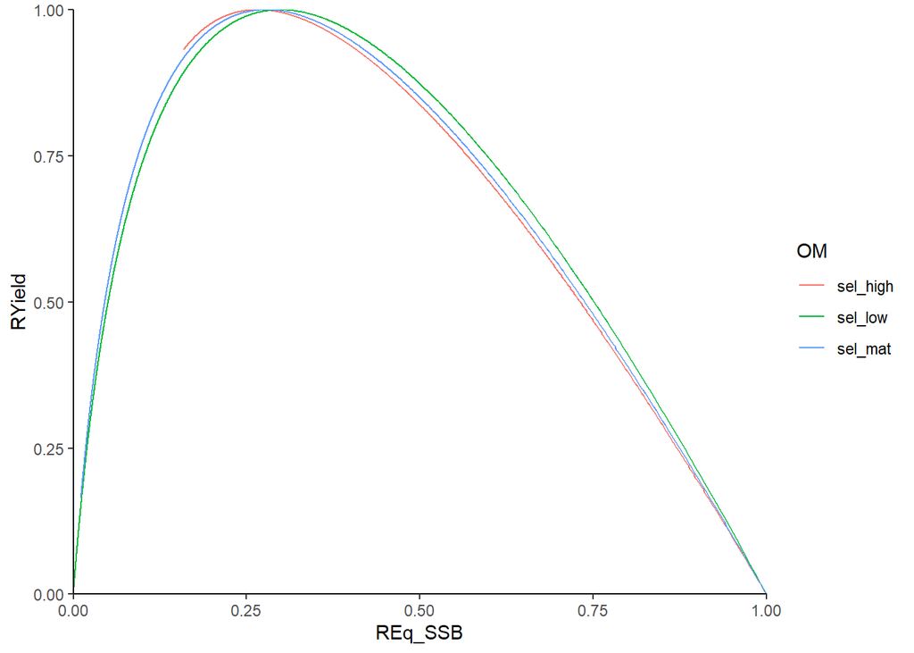

```r
ggplot(D3)+geom_path(mapping=aes(y=RYield,x=REq_SSB,colour=OM)) + theme_classic() +
  scale_x_continuous(limits = c(0,1), expand = c(0, 0)) +
  scale_y_continuous(limits = c(0,1), expand = c(0, 0))
```